# {shinipsum} is now on CRAN

Colin

2020-05-10

I’m very happy to announce that `{shinipsum}` is now on CRAN!

`{shinipsum}` is a package that can help you build `{shiny}` prototypes faster by providing a series of functions that can generate random elements to populate your UI with. If you are familiar with “lorem ipsum”, the fake text generator that is used in software design as a placeholder for text, the idea is the same: generating placeholders for Shiny outputs.

`{shinipsum}` can be installed from CRAN with:

```r
install.packages("shinipsum")
```

You can install this package from GitHub with:

```r
remotes::install_github("Thinkr-open/shinipsum")
```

In this package, a series of functions that generates random placeholders. For example, `random_ggplot()` generates random `{ggplot2}` elements:

```r
library(shinipsum)
```

```r
library(ggplot2)
```

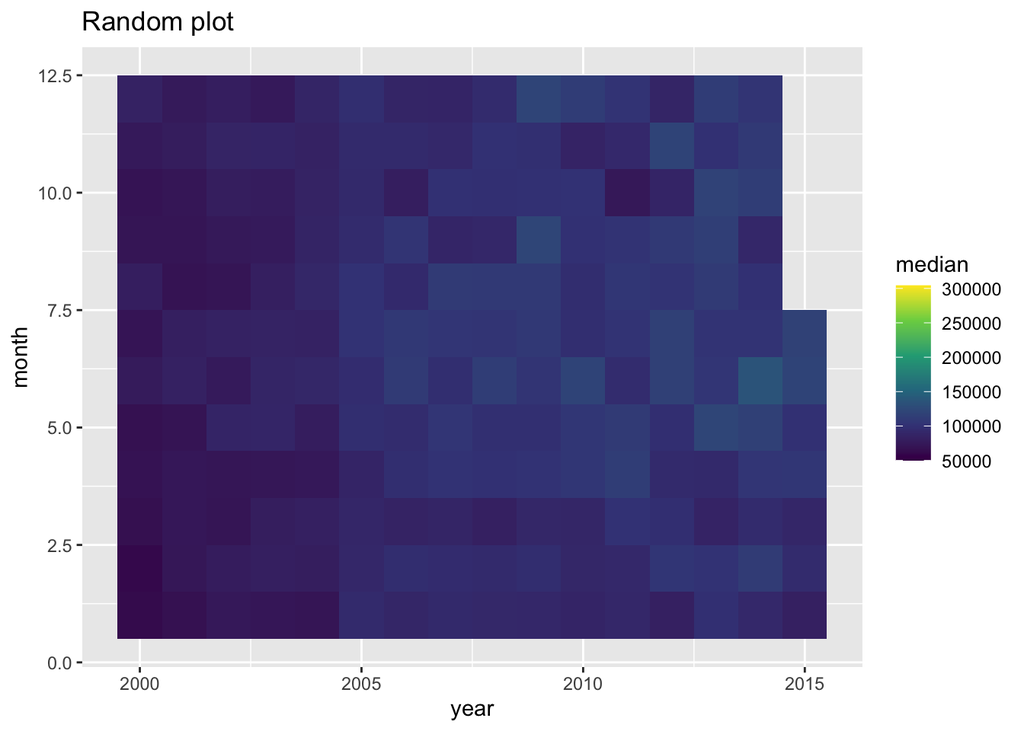

```r
random_ggplot() +
  labs(title = "Random plot")
```

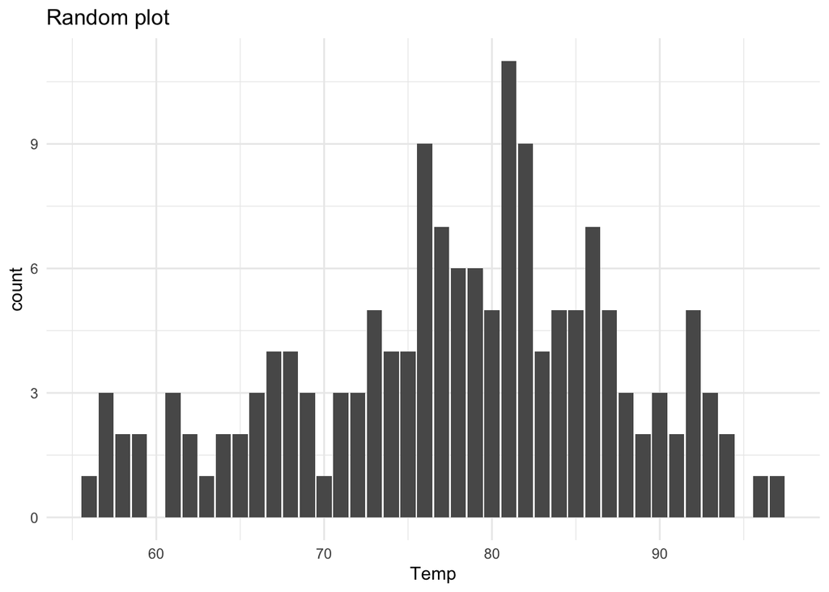

```r
random_ggplot() +
  labs(title = "Random plot")
```

Of course, the idea is to combine this with a Shiny interface, for example `random_ggplot()` will be used with a `renderPlot()` and `plotOutput()`. And as we want to prototype but still be close to what the app might look like, these functions take arguments that can shape the output: for example, `random_ggplot()` has a `type` parameter that can help you select a specific geom.

```r
library(shiny)
library(shinipsum)
library(DT)
ui <- fluidPage(
  h2("A Random DT"),
  DTOutput("data_table"),
  h2("A Random Plot"),
  plotOutput("plot"),
  h2("A Random Text"),
  tableOutput("text")
)

server <- function(input, output, session) {
  output$data_table <- DT::renderDT({
    random_DT(5, 5)
  })
  output$plot <- renderPlot({
    random_ggplot(type = "point")
  })
  output$text <- renderText({
    random_text(nwords = 50)
  })
}
shinyApp(ui, server)
```

Other `{shinipsum}` functions include:

- tables:

```r
random_table(nrow = 3, ncol = 10)
```

```
##   day time  temp activ day.1 time.1 temp.1 activ.1 day.2 time.2
## 1 346  840 36.33     0   346    840  36.33       0   346    840
## 2 346  850 36.34     0   346    850  36.34       0   346    850
## 3 346  900 36.35     0   346    900  36.35       0   346    900
```

- print outputs:

```r
random_print(type = "model")
```

```
##
##  Shapiro-Wilk normality test
##
## data:  datasets::airquality$Ozone
## W = 0.87867, p-value = 2.79e-08
```

… and text, image, ggplotly, dygraph, and DT.

Learn more about `{shinipsum}`:

- [`{shinipsum}` website](https://thinkr-open.github.io/shinipsum/)
- [Chapter 10 Building an “ipsum-app” - Engineering Production-Grade Shiny Apps](https://engineering-shiny.org/stepprotopype.html)